# Project - Predicting Mortality in ICU Patients

Lucie Gillet, Maja Garbulinska, Anthony O’Brien, Mathew Samuel

12/12/2018

# Overview and Motivation:

### Provide an overview of the project goals and the motivation for it. Consider that this will be read by people who did not see your project proposal

With the proliferation of data, there continues to be a shift towards data-driven decision making, especially in the world of healthcare. The ICU represents a particularly interesting opportunity given the numerous data elements collected on patients to monitor their health at this critical juncture in their health. Currently, there are a variety of risk prediction scores that clinicians are able to utilize to gain some insight into the overall health of their patient in the aggregate.

For our project, we wanted to see if we could take advantage of the many data points collected and develop a mortality prediction model based on a patient’s first day in the ICU, which remains a particularly important period in their hospital admission. Such a model would provide physicians with a data-driven, standardized approach to assess the overall health of their patient and also potentially inform clinical decision-making moving forward. For instance, though it may be heuristically clear at times which patients might need increased supervision, a robust and standardized score would provide for a systematic, process-driven method to help hospitals allocate resources on patients that require the most attention.

# Related Work:

### Anything that inspired you, such as a paper, a web site, or something we discussed in class

We were inspired by a paper written by our MIT course faculty on [Real-time mortality prediction in the Intensive Care Unit](https://www.ncbi.nlm.nih.gov/pmc/articles/PMC5977709/). We wanted to tackle a relevant and feasible problem given the scope of the class, so decided to modify the task to develop a mortality prediction based on first day measurements.

# Initial Questions:

### What questions are you trying to answer? How did these questions evolve over the course of the project? What new questions did you consider in the course of your analysis?

In the course of our analysis, one of the greatest challenges we faced was thinking about how we would deal with missing data. While we did initially consider looking at various imputation methods, we decided to develop a parsimonious model with reasonable accuracy given the variety of challenges of imputation in a clinical setting after consulting various clinicians and given the time frame of the project.

# Data:

## Source, scraping method, cleanup, etc

For our Collaborative Data Science in Medicine class, the MIMIC database was hosted in Google Bigquery. We developed sql queries and then combined the dataframe into a temporary folder provisioned in bigquery, from which we imported the data into R with a connection. As we cannot provide account access and for the sake of reproducibility, we placed an extract of the query result in an Rda file to analyze going forward.

# Exploratory Analysis:

What visualizations did you use to look at your data in different ways? What are the different statistical methods you considered? Justify the decisions you made, and show any major changes to your ideas. How did you reach these conclusions?

# Final Analysis: What did you learn about the data? How did you answer the questions? How can you justify your answers?

```r
df <- read.csv(file='../data/260_1123cohort.csv',sep=',', header=TRUE, quote="\'", check.names = FALSE)
load('../data/cohort_1204.Rda')
names(hds)
```

```
##   [1] "subject_id"                    "hadm_id"
##   [3] "icustay_id"                    "ANIONGAP_min"
##   [5] "ANIONGAP_max"                  "ALBUMIN_min"
##   [7] "ALBUMIN_max"                   "BANDS_min"
##   [9] "BANDS_max"                     "BICARBONATE_min"
##  [11] "BICARBONATE_max"               "BILIRUBIN_min"
##  [13] "BILIRUBIN_max"                 "CREATININE_min"
##  [15] "CREATININE_max"                "CHLORIDE_min"
##  [17] "CHLORIDE_max"                  "GLUCOSE_min"
##  [19] "GLUCOSE_max"                   "HEMATOCRIT_min"
##  [21] "HEMATOCRIT_max"                "HEMOGLOBIN_min"
##  [23] "HEMOGLOBIN_max"                "LACTATE_min"
##  [25] "LACTATE_max"                   "PLATELET_min"
##  [27] "PLATELET_max"                  "POTASSIUM_min"
##  [29] "POTASSIUM_max"                 "PTT_min"
```

[output cut: 250 more lines]

First, we exclude all the patients who do not meet our inclusion criteria. Due to physiological differences, we exclude everyone who is under 18 years old.

```r
hds<- hds %>% filter (age>=18)
```

This is the distribution of age now:

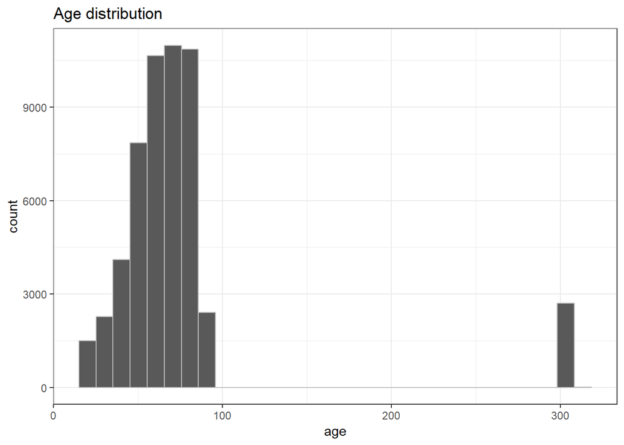

```r
plot1<- ggplot()+
  geom_histogram(aes(x=age), data=hds, colour="grey")+
  theme_bw()+
  ggtitle("Age distribution")
plot1
```

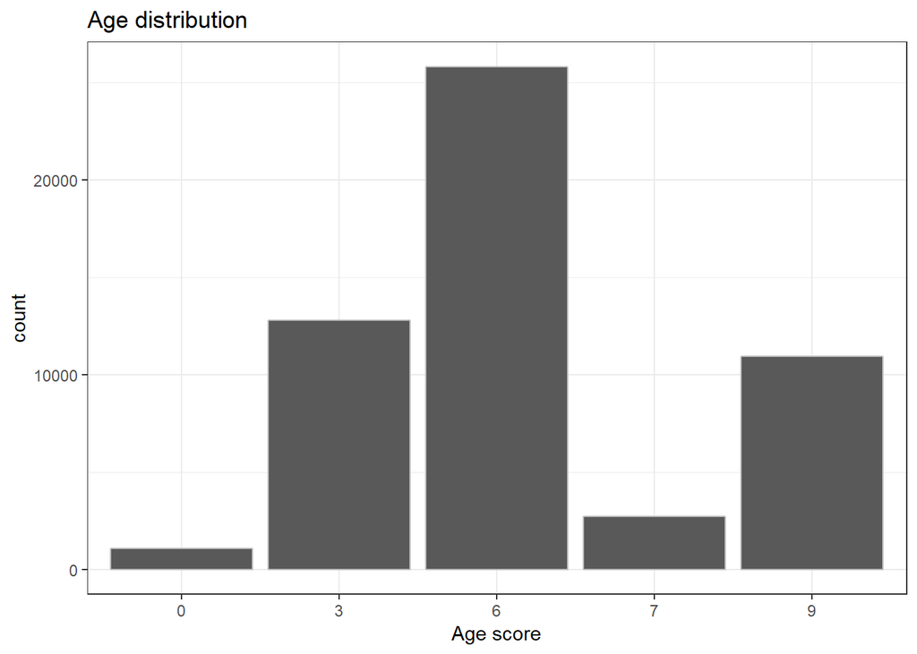

```r
plot2<- ggplot()+
  geom_histogram(aes(x=as.character(age_score)), data=hds, colour="grey", stat="count")+
  theme_bw()+
  ggtitle("Age distribution")+
  xlab("Age score")
plot2
```

Older individuals above 90 are assigned to 7, for a more logical interpretation we assign these individuals to 12 to more accurately reflect the demographics.

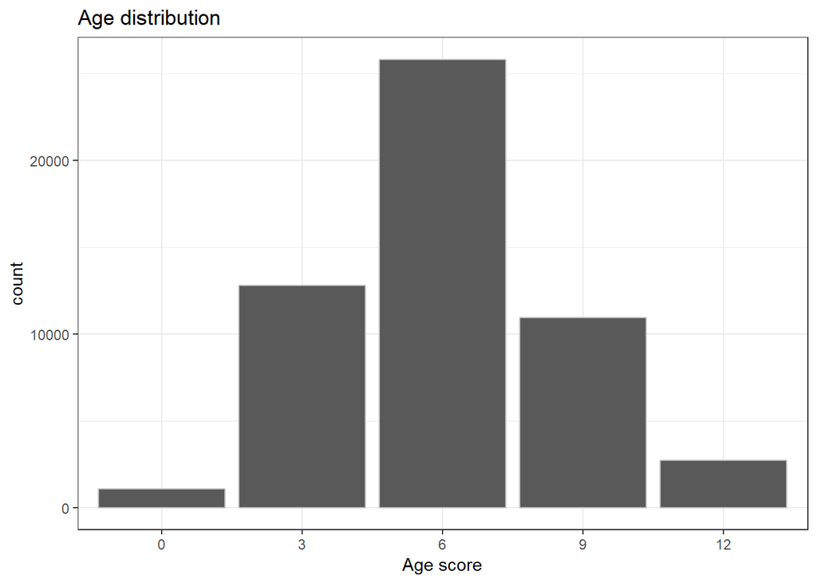

```r
hds<- hds %>%
  mutate(age_score=ifelse(age_score==7,12,age_score))


plot3<-hds %>%
  ggplot()+
  geom_histogram(aes(x=as.factor(age_score)), data=hds, colour="grey", stat="count")+
  theme_bw()+
  ggtitle("Age distribution")+
  xlab("Age score")
plot3
```